# Women in Parliament - Tidy Data

Christos Gkenas

Fri 06 Dec 2019 (12:41:13)

[figure not shown]

# Objectives

*Explore the geographical and time trends for the percentage of women in national parliaments.*

# Understanding the Data

## The World Bank Data

The raw data for *“Proportion of seats held by women in national parliaments”* includes the percentage of women in parliament (*“single or lower parliamentary chambers only”*) by country (region) and year. It can be downloaded from:

- https://data.worldbank.org/indicator/SG.GEN.PARL.ZS

As part of its “open data” mission the World Bank offers *“free and open access to global development data”* kindly licensed under the “Creative Commons Attribution 4.0 (CC-BY 4.0)”.

## Source Data

The data originates from the “Inter-Parliamentary Union” (IPU)[^ipuwebsite] which provides an *“Archive of statistical data on the percentage of women in national parliaments”* going back to 1997 on a monthly basis:

- http://archive.ipu.org/wmn-e/classif-arc.htm

The World Bank data is for “single or lower parliamentary chambers only”, while the IPU also presents data for “Upper Houses or Senates”. Moreover, the IPU provides the actual numbers used to calculate the percentages (which the World Bank does not).

## Data limitations

Take caution when interpreting these data, as parliamentary systems vary from country to country, and in some cases over time. Some of the issues to consider include:

- Who has, and who does not have, the right to become a Member of Parliament (MP)?
- How does someone become an MP? Through democratic elections? How is “democratic election” defined?
- What is the real power of MPs and their parliament? Can MPs make a difference?

## Data definitions & assumptions

### “Women”

The definition for “women” is not given, so we will assume that it refers to a binary classification for gender (sex).

### “Country (Region)”

The definition of countries and regions can change over time. (e.g. formation of new countries after conflicts, new member states joining a pre-existing collective). How are these changes reflected in the data? How do they affect the interpretation?

## Pro tip

Understand the limitations of your data before anybody else points them out to you.

# About the data file

The data is stored in a file called: `API_SG.GEN.PARL.ZS_DS2_en_csv_v2_511371.csv`

To simplify things we have copied it to `WB-WiP.csv` (which also allows us to maintain the original file in case something goes wrong).

## Pro tip

Always keep a backup copy of the data. Alternatively, set the data file(s) to “read-only” to protect it from being overwritten or modified.

# Importing the data

```r
library(data.table)
library(here)
wip <- fread(here("data", "WB-WiP.csv"),
             skip = 4, header = TRUE,
             check.names = TRUE)
```

# Continue from here…

## Structure the Data

```r
wip
```

```
##      Country.Name Country.Code
##   1:        Aruba          ABW
##   2:  Afghanistan          AFG
##   3:       Angola          AGO
##   4:      Albania          ALB
##   5:      Andorra          AND
##  ---
## 260:       Kosovo          XKX
## 261:  Yemen, Rep.          YEM
## 262: South Africa          ZAF
## 263:       Zambia          ZMB
## 264:     Zimbabwe          ZWE
##                                                     Indicator.Name
##   1: Proportion of seats held by women in national parliaments (%)
##   2: Proportion of seats held by women in national parliaments (%)
```

[output cut: 81 more lines]

```r
class(wip)
```

```
## [1] "data.table" "data.frame"
```

```r
str(wip)
```

```
## Classes 'data.table' and 'data.frame':   264 obs. of  65 variables:
##  $ Country.Name  : chr  "Aruba" "Afghanistan" "Angola" "Albania" ...
##  $ Country.Code  : chr  "ABW" "AFG" "AGO" "ALB" ...
##  $ Indicator.Name: chr  "Proportion of seats held by women in national parliaments (%)" "Proportion of seats held by women in national parliaments (%)" "Proportion of seats held by women in national parliaments (%)" "Proportion of seats held by women in national parliaments (%)" ...
##  $ Indicator.Code: chr  "SG.GEN.PARL.ZS" "SG.GEN.PARL.ZS" "SG.GEN.PARL.ZS" "SG.GEN.PARL.ZS" ...
##  $ X1960         : logi  NA NA NA NA NA NA ...
##  $ X1961         : logi  NA NA NA NA NA NA ...
##  $ X1962         : logi  NA NA NA NA NA NA ...
##  $ X1963         : logi  NA NA NA NA NA NA ...
##  $ X1964         : logi  NA NA NA NA NA NA ...
##  $ X1965         : logi  NA NA NA NA NA NA ...
##  $ X1966         : logi  NA NA NA NA NA NA ...
##  $ X1967         : logi  NA NA NA NA NA NA ...
##  $ X1968         : logi  NA NA NA NA NA NA ...
##  $ X1969         : logi  NA NA NA NA NA NA ...
```

[output cut: 52 more lines]

```r
View(wip)
names(wip)
```

```
##  [1] "Country.Name"   "Country.Code"   "Indicator.Name" "Indicator.Code"
##  [5] "X1960"          "X1961"          "X1962"          "X1963"
##  [9] "X1964"          "X1965"          "X1966"          "X1967"
## [13] "X1968"          "X1969"          "X1970"          "X1971"
## [17] "X1972"          "X1973"          "X1974"          "X1975"
## [21] "X1976"          "X1977"          "X1978"          "X1979"
## [25] "X1980"          "X1981"          "X1982"          "X1983"
## [29] "X1984"          "X1985"          "X1986"          "X1987"
## [33] "X1988"          "X1989"          "X1990"          "X1991"
## [37] "X1992"          "X1993"          "X1994"          "X1995"
## [41] "X1996"          "X1997"          "X1998"          "X1999"
## [45] "X2000"          "X2001"          "X2002"          "X2003"
## [49] "X2004"          "X2005"          "X2006"          "X2007"
## [53] "X2008"          "X2009"          "X2010"          "X2011"
## [57] "X2012"          "X2013"          "X2014"          "X2015"
## [61] "X2016"          "X2017"          "X2018"          "X2019"
## [65] "V65"
```

## Removing column V65

```r
wip[, .N, by=, (V65)]
```

```
##    V65   N
## 1:  NA 264
```

## Confirming “Infdicator.Name” and “Indicator.Code” have the same values for all observations

```r
wip[, .N, by=, (Indicator.Name)]
```

```
##                                                   Indicator.Name   N
## 1: Proportion of seats held by women in national parliaments (%) 264
```

```r
wip[, .N, by=, (Indicator.Code)]
```

```
##    Indicator.Code   N
## 1: SG.GEN.PARL.ZS 264
```

## Removing & Renaming columns

```r
wip[, c("Indicator.Name", "Indicator.Code", "V65"):=NULL]
wip
```

```
##      Country.Name Country.Code X1960 X1961 X1962 X1963 X1964 X1965 X1966
##   1:        Aruba          ABW    NA    NA    NA    NA    NA    NA    NA
##   2:  Afghanistan          AFG    NA    NA    NA    NA    NA    NA    NA
##   3:       Angola          AGO    NA    NA    NA    NA    NA    NA    NA
##   4:      Albania          ALB    NA    NA    NA    NA    NA    NA    NA
##   5:      Andorra          AND    NA    NA    NA    NA    NA    NA    NA
##  ---
## 260:       Kosovo          XKX    NA    NA    NA    NA    NA    NA    NA
## 261:  Yemen, Rep.          YEM    NA    NA    NA    NA    NA    NA    NA
## 262: South Africa          ZAF    NA    NA    NA    NA    NA    NA    NA
## 263:       Zambia          ZMB    NA    NA    NA    NA    NA    NA    NA
## 264:     Zimbabwe          ZWE    NA    NA    NA    NA    NA    NA    NA
##      X1967 X1968 X1969 X1970 X1971 X1972 X1973 X1974 X1975 X1976 X1977
##   1:    NA    NA    NA    NA    NA    NA    NA    NA    NA    NA    NA
##   2:    NA    NA    NA    NA    NA    NA    NA    NA    NA    NA    NA
```

[output cut: 57 more lines]

```r
names(wip)
```

```
##  [1] "Country.Name" "Country.Code" "X1960"        "X1961"
##  [5] "X1962"        "X1963"        "X1964"        "X1965"
##  [9] "X1966"        "X1967"        "X1968"        "X1969"
## [13] "X1970"        "X1971"        "X1972"        "X1973"
## [17] "X1974"        "X1975"        "X1976"        "X1977"
## [21] "X1978"        "X1979"        "X1980"        "X1981"
## [25] "X1982"        "X1983"        "X1984"        "X1985"
## [29] "X1986"        "X1987"        "X1988"        "X1989"
## [33] "X1990"        "X1991"        "X1992"        "X1993"
## [37] "X1994"        "X1995"        "X1996"        "X1997"
## [41] "X1998"        "X1999"        "X2000"        "X2001"
## [45] "X2002"        "X2003"        "X2004"        "X2005"
## [49] "X2006"        "X2007"        "X2008"        "X2009"
## [53] "X2010"        "X2011"        "X2012"        "X2013"
## [57] "X2014"        "X2015"        "X2016"        "X2017"
## [61] "X2018"        "X2019"
```

```r
setnames(wip, c("Country.Name", "Country.Code"), c("Country", "Code"))
head(names(wip))
```

```
## [1] "Country" "Code"    "X1960"   "X1961"   "X1962"   "X1963"
```

```r
tail(names(wip))
```

```
## [1] "X2014" "X2015" "X2016" "X2017" "X2018" "X2019"
```

## Reshaping to long format & Removing the missing data

```r
WP <- melt(wip,
           id.vars = c("Country", "Code"),
           measure = patterns("^X"),
           variable.name = "YearC",
           value.name = c("pctWiP"),
           na.rm = TRUE)
WP
```

```
##                    Country Code YearC    pctWiP
##    1:          Afghanistan  AFG X1990  3.700000
##    2:               Angola  AGO X1990 14.500000
##    3:              Albania  ALB X1990 28.800000
##    4:           Arab World  ARB X1990  3.891439
##    5: United Arab Emirates  ARE X1990  0.000000
##   ---
## 5105:                Samoa  WSM X2018 10.000000
## 5106:          Yemen, Rep.  YEM X2018  0.000000
## 5107:         South Africa  ZAF X2018 42.300000
## 5108:               Zambia  ZMB X2018 18.000000
## 5109:             Zimbabwe  ZWE X2018 31.500000
```

```r
View(WP)
```

## Final Tweaks

```r
WP[, `:=`(Year=as.numeric(gsub("X","", YearC)),
          Ratio = (100-pctWiP)/pctWiP)][
            , YearC:=NULL]
setcolorder(WP, c("Country", "Code", "Year", "pctWiP", "Ratio"))
WP
```

```
##                    Country Code Year    pctWiP     Ratio
##    1:          Afghanistan  AFG 1990  3.700000 26.027027
##    2:               Angola  AGO 1990 14.500000  5.896552
##    3:              Albania  ALB 1990 28.800000  2.472222
##    4:           Arab World  ARB 1990  3.891439 24.697433
##    5: United Arab Emirates  ARE 1990  0.000000       Inf
##   ---
## 5105:                Samoa  WSM 2018 10.000000  9.000000
## 5106:          Yemen, Rep.  YEM 2018  0.000000       Inf
## 5107:         South Africa  ZAF 2018 42.300000  1.364066
## 5108:               Zambia  ZMB 2018 18.000000  4.555556
## 5109:             Zimbabwe  ZWE 2018 31.500000  2.174603
```

## Time trends for Portugal

```r
WP[Country %in% "Portugal"]
```

```
##      Country Code Year pctWiP     Ratio
##  1: Portugal  PRT 1990    7.6 12.157895
##  2: Portugal  PRT 1997   13.0  6.692308
##  3: Portugal  PRT 1998   13.0  6.692308
##  4: Portugal  PRT 1999   18.7  4.347594
##  5: Portugal  PRT 2000   17.4  4.747126
##  6: Portugal  PRT 2001   18.7  4.347594
##  7: Portugal  PRT 2002   19.1  4.235602
##  8: Portugal  PRT 2003   19.1  4.235602
##  9: Portugal  PRT 2004   19.1  4.235602
## 10: Portugal  PRT 2005   21.3  3.694836
## 11: Portugal  PRT 2006   21.3  3.694836
## 12: Portugal  PRT 2007   28.3  2.533569
## 13: Portugal  PRT 2008   28.3  2.533569
## 14: Portugal  PRT 2009   27.4  2.649635
## 15: Portugal  PRT 2010   27.4  2.649635
## 16: Portugal  PRT 2011   28.7  2.484321
## 17: Portugal  PRT 2012   28.7  2.484321
## 18: Portugal  PRT 2013   28.7  2.484321
## 19: Portugal  PRT 2014   31.3  2.194888
## 20: Portugal  PRT 2015   34.8  1.873563
## 21: Portugal  PRT 2016   34.8  1.873563
## 22: Portugal  PRT 2017   34.8  1.873563
## 23: Portugal  PRT 2018   34.8  1.873563
##      Country Code Year pctWiP     Ratio
```

## Time trends for Greece

```r
GR<- WP[Country %in% "Greece"]
GR
```

```
##     Country Code Year pctWiP     Ratio
##  1:  Greece  GRC 1990    6.7 13.925373
##  2:  Greece  GRC 1997    6.3 14.873016
##  3:  Greece  GRC 1998    6.3 14.873016
##  4:  Greece  GRC 1999    6.3 14.873016
##  5:  Greece  GRC 2000    8.7 10.494253
##  6:  Greece  GRC 2001    8.7 10.494253
##  7:  Greece  GRC 2002    8.7 10.494253
##  8:  Greece  GRC 2003    8.7 10.494253
##  9:  Greece  GRC 2004   14.0  6.142857
## 10:  Greece  GRC 2005   13.0  6.692308
## 11:  Greece  GRC 2006   13.0  6.692308
## 12:  Greece  GRC 2007   14.7  5.802721
## 13:  Greece  GRC 2008   14.7  5.802721
## 14:  Greece  GRC 2009   17.3  4.780347
## 15:  Greece  GRC 2010   17.3  4.780347
## 16:  Greece  GRC 2011   18.7  4.347594
## 17:  Greece  GRC 2012   21.0  3.761905
## 18:  Greece  GRC 2013   21.0  3.761905
## 19:  Greece  GRC 2014   21.0  3.761905
## 20:  Greece  GRC 2015   19.7  4.076142
## 21:  Greece  GRC 2016   19.7  4.076142
## 22:  Greece  GRC 2017   18.3  4.464481
## 23:  Greece  GRC 2018   18.7  4.347594
##     Country Code Year pctWiP     Ratio
```

## Visualisation for PT

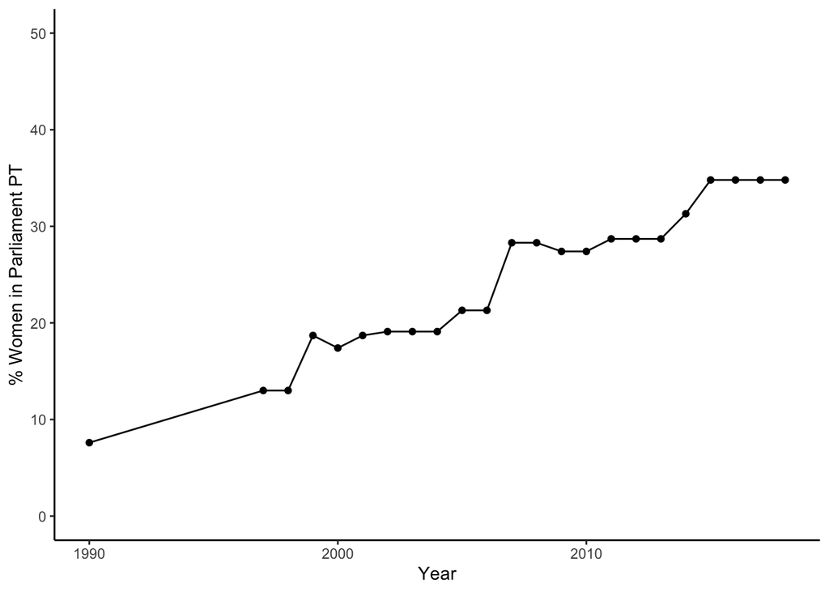

```r
library(ggplot2); theme_set(theme_classic())
library(magrittr)
WP[Country %in% "Portugal"] %>%
  ggplot(aes(Year, pctWiP)) +
  geom_line() + geom_point() +
  scale_y_continuous(limits = c(0, 50)) +
  ylab("% Women in Parliament PT")
```

## Visualisation for GR

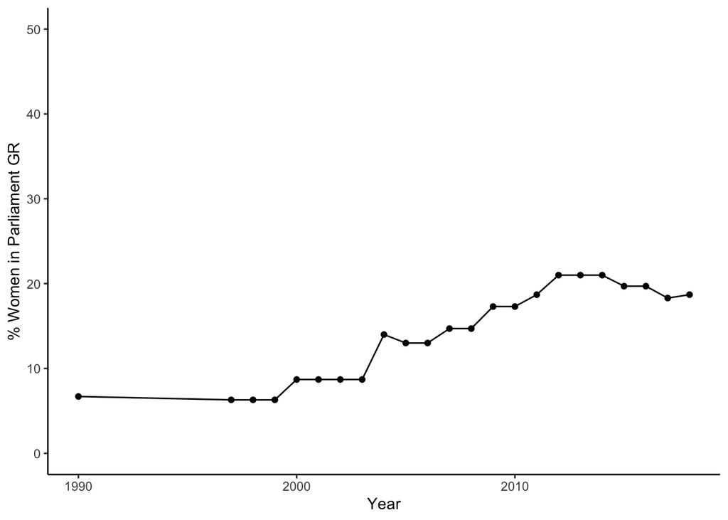

```r
GR<- WP[Country %in% "Greece"] %>%
  ggplot(aes(Year, pctWiP)) +
  geom_line() + geom_point() +
  scale_y_continuous(limits = c(0, 50)) +
  ylab("% Women in Parliament GR")
GR
```

## PT, GR vs other EU countries

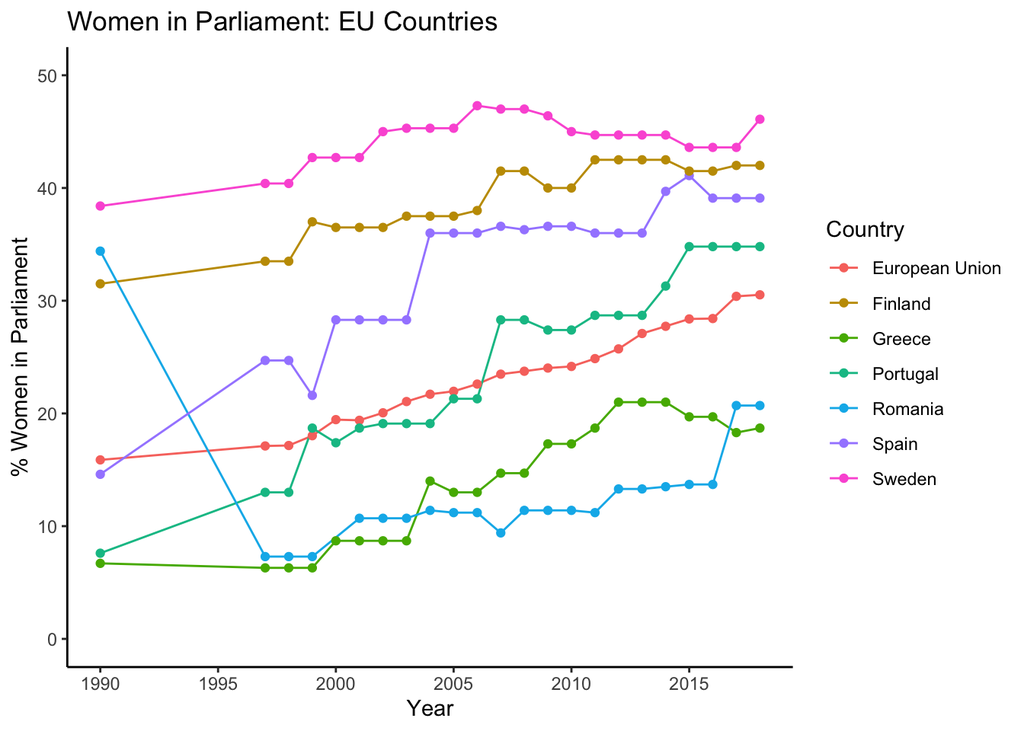

```r
WP[Country %in% c("Portugal", "Greece", "Sweden", "Spain",
                  "Hingary", "Romania", "Finland", "Germnay",
                  "European Union")] %>%
  ggplot(aes(Year, pctWiP, group=Country)) +
  geom_line(aes(color=Country)) +
  geom_point(aes(color=Country)) +
  scale_x_continuous(breaks=seq(1990, 2020, 5)) +
  scale_y_continuous(limits = c(0, 50),
                     breaks=seq(0, 50, by=10)) +
  ggtitle("Women in Parliament: EU Countries") +
  ylab("% Women in Parliament")
```

# Countrues with the % of women in parliament

```r
WP[order(-pctWiP), head(.SD, 10)]
```

```
##     Country Code Year pctWiP     Ratio
##  1:  Rwanda  RWA 2013   63.8 0.5673981
##  2:  Rwanda  RWA 2014   63.8 0.5673981
##  3:  Rwanda  RWA 2015   63.8 0.5673981
##  4:  Rwanda  RWA 2016   63.8 0.5673981
##  5:  Rwanda  RWA 2017   61.3 0.6313214
##  6:  Rwanda  RWA 2018   61.3 0.6313214
##  7:  Rwanda  RWA 2008   56.3 0.7761989
##  8:  Rwanda  RWA 2009   56.3 0.7761989
##  9:  Rwanda  RWA 2010   56.3 0.7761989
## 10:  Rwanda  RWA 2011   56.3 0.7761989
```

# Countries with % by year

```r
WP[order(Year, -pctWiP), head(.SD, 1), by = Year]
```

```
##     Year Country Code pctWiP     Ratio
##  1: 1990  Sweden  SWE   38.4 1.6041667
##  2: 1997  Sweden  SWE   40.4 1.4752475
##  3: 1998  Sweden  SWE   40.4 1.4752475
##  4: 1999  Sweden  SWE   42.7 1.3419204
##  5: 2000  Sweden  SWE   42.7 1.3419204
##  6: 2001  Sweden  SWE   42.7 1.3419204
##  7: 2002  Sweden  SWE   45.0 1.2222222
##  8: 2003  Rwanda  RWA   48.8 1.0491803
##  9: 2004  Rwanda  RWA   48.8 1.0491803
## 10: 2005  Rwanda  RWA   48.8 1.0491803
## 11: 2006  Rwanda  RWA   48.8 1.0491803
## 12: 2007  Rwanda  RWA   48.8 1.0491803
## 13: 2008  Rwanda  RWA   56.3 0.7761989
## 14: 2009  Rwanda  RWA   56.3 0.7761989
## 15: 2010  Rwanda  RWA   56.3 0.7761989
## 16: 2011  Rwanda  RWA   56.3 0.7761989
## 17: 2012  Rwanda  RWA   56.3 0.7761989
## 18: 2013  Rwanda  RWA   63.8 0.5673981
## 19: 2014  Rwanda  RWA   63.8 0.5673981
## 20: 2015  Rwanda  RWA   63.8 0.5673981
## 21: 2016  Rwanda  RWA   63.8 0.5673981
## 22: 2017  Rwanda  RWA   61.3 0.6313214
## 23: 2018  Rwanda  RWA   61.3 0.6313214
##     Year Country Code pctWiP     Ratio
```

# Merging Continent

```r
library(countrycode)
c1 <-as.data.table(codelist)[, .(continent, wb)]
setnames(c1, c("continent", "wb"),
         c("Continent", "Code"))
cWP<- c1[WP, on="Code"]
cWP
```

```
##       Continent Code              Country Year    pctWiP     Ratio
##    1:      Asia  AFG          Afghanistan 1990  3.700000 26.027027
##    2:    Africa  AGO               Angola 1990 14.500000  5.896552
##    3:    Europe  ALB              Albania 1990 28.800000  2.472222
##    4:      <NA>  ARB           Arab World 1990  3.891439 24.697433
##    5:      Asia  ARE United Arab Emirates 1990  0.000000       Inf
##   ---
## 5105:   Oceania  WSM                Samoa 2018 10.000000  9.000000
## 5106:      Asia  YEM          Yemen, Rep. 2018  0.000000       Inf
## 5107:    Africa  ZAF         South Africa 2018 42.300000  1.364066
## 5108:    Africa  ZMB               Zambia 2018 18.000000  4.555556
## 5109:    Africa  ZWE             Zimbabwe 2018 31.500000  2.174603
```

# Highest % by year % continent

```r
cWP[Year %in% c(1990, 2018) & !is.na(Continent)][
  order(Year, -pctWiP), head(.SD, 1),
  by = .(Year, Continent)][
    order(Continent, Year),
    .(Continent, Year, Country, pctWiP)]
```

```
##     Continent Year       Country pctWiP
##  1:    Africa 1990 Guinea-Bissau   20.0
##  2:    Africa 2018        Rwanda   61.3
##  3:  Americas 1990        Guyana   36.9
##  4:  Americas 2018          Cuba   53.2
##  5:      Asia 1990       Armenia   35.6
##  6:      Asia 2018   Timor-Leste   33.8
##  7:    Europe 1990        Sweden   38.4
##  8:    Europe 2018        Sweden   46.1
##  9:   Oceania 1990   New Zealand   14.4
## 10:   Oceania 2018   New Zealand   38.3
```

[figure not shown]